# FigureYa212drugTargetV2

**Author(s)**: Xiaofan Lu  
**Reviewer(s)**: Ying Ge  
**Date**: 2025-10-31

## Academic Citation

If you use this code in your work or research, we kindly request that you cite our publication:

Xiaofan Lu, et al. (2025). FigureYa: A Standardized Visualization Framework for Enhancing Biomedical Data Interpretation and Research Efficiency. iMetaMed. https://doi.org/10.1002/imm3.70005

To use this analysis approach, please cite the following article:

Chen Yang, Xiaowen Huang, Yan Li, Junfei Chen, Yuanyuan Lv, Shixue Dai, Prognosis and personalized treatment prediction in TP53-mutant hepatocellular carcinoma: an in silico strategy towards precision oncology, Briefings in Bioinformatics, bbaa164, https://doi.org/10.1093/bib/bbaa164

## 需求描述 Requirement description

需求一：这篇文章的Figure5F，G图，同时要包括按照文中的方法对非肿瘤组织进行纯化。

需求二：根据PRISM和CTRP2.0药物敏感性AUC值数据、以及CCLE表达谱数据，预测TCGA亚组潜在性治疗药物。 FigureYa105GDSC也用到了pRRophetic。不同于FigureYa105GDSC，这个数据是药物敏感性AUC值，以及药物的范围更加广泛。里面提到一个算法ISOpureR，通过解卷积消除肿瘤样本中掺杂的正常样本，提纯肿瘤表达矩阵，感觉也还不错。

Requirement one: Figure 5F and G of this article, which also includes purification of non-tumor tissues according to the methods in the article.

Requirement two: According to the PRISM and CTRP2.0 drug sensitivity AUC value data, as well as the CCLE expression profile data, predict potential therapeutic drugs for TCGA subgroups.

[figure not shown]

From https://academic.oup.com/bib/advance-article/doi/10.1093/bib/bbaa164/5891146

Figure 5. Identification of candidate agents with higher drug sensitivity in high-PPS score patients. (A) A venn diagram for summarizing included compounds from CTRP and PRISM datasets (see also Table S12). (B) Volcano plot of differential expression between bulk HCC samples and hepatoma cell lines (Wilcoxon rank-sum test: adjust P < 0.05, and log2FC > 1). Stroma markers are highlighted in deep colour (see also Table S13). (C) Volcano plot of differential expression between purified HCC samples and hepatoma cell lines (Wilcoxon rank-sum test: adjust P < 0.05, and log2FC > 1). Stroma markers are highlighted in deep color (see also Table S13). (D) Comparison of estimated sorafenib’s sensitivity (logAUC) between PI3K-MTOR altered and unaltered groups. (E) Schematic outlining the **strategy to identify agents** with **higher drug sensitivity in high PPS score patients**. (F) The results of Spearman’s correlation analysis and differential drug response analysis of six **CTRP-derived compounds**. (G) The results of Spearman’s correlation analysis and differential drug response analysis of six **PRISM-derived compounds**. Note that lower values on the y-axis of boxplots imply greater drug sensitivity.

**Concepts involved:**

- PPS：prognosis-associated signature (PPS), which had superior ability to predict **survival in TP53-mutant patients** compared with previously established population-based signatures. Further, three therapeutic targets (CANT1, CBFB and PKM) and two agents (irinotecan and YM-155) were identified for those high-risk patients, holding the potential to improve current population-based therapeutic strategies in HCC.
- Two drug sensitivity databases:
  - The [CTRP2.0](https://portals.broadinstitute.org/ctrp.v2.1/) contains the sensitivity data for **481 compounds over 835 CCLs**
  - the [PRISM](https://www.theprismlab.org) contains the sensitivity data for **1448 compounds over 482 CCLs**.
  - Both two datasets provide the **area under the dose–response curve (area under the curve—AUC)** values as a **measure of drug sensitivity**, and lower AUC values indicate **increased sensitivity to treatment**.
- CCLE和KNN：
  - Expression profile data and somatic mutation data of human cancer cell lines (CCLs) were obtained from the Broad Institute-**Cancer Cell Line Encyclopedia (CCLE)** project (https://portals.broadinstitute.org/ccle/)
  - **K-nearest neighbor (k-NN)** imputation was applied to impute the missing AUC values. Before imputation, compounds with more than 20% of missing data were excluded.
  - Because the CCLs in both datasets were obtained from the CCLE project, molecular data in **CCLE were thus used for subsequent CTRP and PRISM analyses.**

## 应用场景 Application Scenarios

筛选对癌症亚组可能有效的化合物/药物，例文用了多种方式相互佐证。

Identify compounds/drugs that may be effective for cancer subgroups, and the article uses multiple methods to corroborate each other.

- With PRISM and CTRP, 12 candidate compounds identified showed a higher drug sensitivity in PPS score-high patients.
- **above analyses alone could not support** the conclusion that these compounds had therapeutic effect in HCC. Therefore, **multiple- perspective analyses** were subsequently conducted to investigate the therapeutic potential of these compounds in HCC.
  - We first used the **CMap analysis** to find compounds of which gene expression patterns were oppositional to the HCC-specific expression patterns (i.e. gene expression increased in tumor tissues but decreased by treatment of certain compounds).
  - Secondly, **fold-change differences of the expression levels (including mRNA- and protein-level) of candidates’ drug targets** between tumor and normal tissue were calculated, and a higher fold change value indicated a greater potential of candidate agent for HCC treatment.
  - Thirdly, a comprehensive **literature search** was performed in PubMed (https://www.ncbi.nlm.nih. gov/pubmed/) to find out the experimental and clinical evidence of candidate compounds in treating HCC.

其中CMap analysis及多种证据的结果展示可参考FigureYa213customizeHeatmap

Among them, the results of CMap analysis and multiple lines of evidence can be referred to FigureYa213customizeHeatmap.

下面带你实现前两种方法：利用细胞系表达谱（CCLE）及药敏结果（PRISM和CTRP），预测癌症样本的药敏结果。

Next, we will guide you through the implementation of the first two methods: using cell line expression profiles (CCLE) and drug sensitivity results (PRISM and CTRP) to predict drug sensitivity results for cancer samples.

## 环境设置 Environment Setup

```r
source("install_dependencies.R")
```

```
## Starting R package installation for FigureYa212drugTargetV2...
## ===========================================
##
## Installing Bioconductor packages...
## Package already installed: impute
## Package already installed: sva
##
## Installing CRAN packages...
## Package already installed: tidyverse
## Package already installed: ISOpureR
## Package already installed: SimDesign
## Package already installed: cowplot
## Package already installed: ridge
## Package already installed: car
##
## ===========================================
## Package installation completed!
```

```r
source("predict_from_cgp.R") # from pRRophetic package
if (!requireNamespace("ridge", quietly = TRUE)) {
  install.packages("ridge")
}
library(tidyverse) # for reading MAF files
library(ISOpureR) # for purifying expression profiles
library(impute) # for KNN imputation of drug sensitivity data
library(SimDesign) # for suppressing output messages during drug sensitivity prediction
```

```r
library(ggplot2) # for plotting
library(cowplot) # for combining plots
library(ridge) # for ridge regression

Sys.setenv(LANGUAGE = "en") # display error messages in English
options(stringsAsFactors = FALSE) # prevent character columns from being converted to factors
```

自定义函数显示进度 | Custom function to display progress

```r
display.progress = function (index, totalN, breakN=20) {
  if ( index %% ceiling(totalN/breakN)  ==0  ) {
    cat(paste(round(index*100/totalN), "% ", sep=""))
  }
}
```

## 输入文件 Input File

LIHC.TPM.txt，基因表达矩阵。计算PPS得分和药敏预测，都基于这个表达矩阵。实际应用时把这个表达矩阵替换成你自己的数据。

data_mutations_mskcc.txt，maf突变数据，用于提取癌症亚型，例文提取的是TP53-mutant patients。

LIHC.TPM.txt, gene expression matrix. Both PPS score calculation and drug sensitivity prediction are based on this expression matrix. In practical applications, replace this expression matrix with your own data.

data_mutations_mskcc.txt, MAF mutation data, used to extract cancer subtypes. The example extracts TP53-mutant patients.

以下文件通用，使用时请引用原文。

The following files are common and should be cited in the original text when used.

- 17gene.txt，用于计算PPS得分。17-gene set in the model with the largest C-index value was considered as PPS. Table S3.
- CTRP_AUC_raw.txt，用于制作CTRP AUC矩阵. To generate the CTRP AUC matrix. Source: Correlating chemical sensitivity and basal gene expression reveals mechanism of action，2016 Nature Chemical Biology，Supplementary Data Set 1 2
- CTRP_ccl_anno.txt，CTRP_cpd_anno.txt, from Supplementary Data Set 1，Supplementary Data Set 2
- PRISM_AUC.txt，from https://depmap.org/portal/download/ Drug sensitivity AUC (PRISM Repurposing Secondary Screen) 19Q4
- CCLE_RNAseq_rsem_genes_tpm_20180929.txt，细胞系表达谱，作为药敏预测时的训练集。Cell line expression profile, as train dataset for drug sensitivity prediction, from https://portals.broadinstitute.org/ccle/data.

```r
# 1.读取肝癌TPM表达谱 Reading LIHC TPM expression profile
expr <- read.table("LIHC.TPM.txt",sep = "\t",row.names = 1,check.names = F,stringsAsFactors = F,header = T)
normsam <- colnames(expr[,which(substr(colnames(expr),11,12) == "11")])
tumosam <- colnames(expr[,which(substr(colnames(expr),11,12) == "01")])

# 2.读取maf突变文件(于cBioPortal下载) Reading MAF mutation file (downloaded from cBioPortal)
maf <- read_tsv("data_mutations_mskcc.txt", comment = "#")
maf$Tumor_Sample_Barcode <- paste0("LIHC",substr(maf$Tumor_Sample_Barcode,8,15))

# 提取既有表达数据又有突变数据的肿瘤样本 Extract tumor samples with both expression data and mutation data
tumosam <- intersect(tumosam,unique(maf$Tumor_Sample_Barcode))
maf <- maf[which(maf$Tumor_Sample_Barcode %in% tumosam),]
expr <- expr[,c(tumosam,normsam)]

# 3.提取TP53突变信息，并创建样本注释 Extract TP53 mutation information and create sample annotation
tp53 <- c()
for (i in tumosam) {
  tmp <- maf[which(maf$Tumor_Sample_Barcode == i),]
  if(is.element("TP53", tmp$Hugo_Symbol)) { # 如果存在TP53 突变
    tp53 <- c(tp53,1) # 记录1 Record 1
  } else {
    tp53 <- c(tp53,0) # 否则记录0 Otherwise record 0
  }
}
names(tp53) <- tumosam

# 取出有TP53突变的患者 Extract patients with TP53 mutations
tp53.mutsam <- names(tp53[which(tp53 == 1)])
```

## 计算PPS得分 Calculate PPS score

17-gene set in the model with the largest C-index value was considered as PPS

Refer to “Development of 17 gene-based PPS in TP53-mutant HCCs”

```r
# 1.读取17-gene signature，计算PPS得分(原文Table S3) Reading 17-gene  signature and calculating PPS score (original Table S3)
signature <- read.table("17gene.txt",sep = "\t",row.names = 1,check.names = F,stringsAsFactors = F,header = T)
dim(signature)
```

```
## [1] 17  3
```

```r
# 计算pps，用到TP53突变患者的17个基因的表达矩阵 Calculating pps, using the expression matrix of 17 genes in TP53 mutant patients
pps <- as.numeric(apply(t(log2(expr[rownames(signature),tp53.mutsam] + 1)), 1, function(x) {x %*% signature$Coefficient}))

# 2.标准化，把pps处理到0-1之间 Standardization, processing pps between 0-1
range01 <- function(x){(x-min(x))/(max(x)-min(x))}
npps <- range01(pps)

# 3.创建样本信息 Creating sample information
Sinfo <- data.frame(PPS = npps,
                    TP53 = tp53[tp53.mutsam],
                    row.names = tp53.mutsam,
                    stringsAsFactors = F)
head(Sinfo)
```

```
##                    PPS TP53
## LIHC-5258-01 0.9779005    1
## LIHC-5259-01 0.3889252    1
## LIHC-5263-01 0.6420745    1
## LIHC-A10R-01 0.4888123    1
## LIHC-A10U-01 0.5220735    1
## LIHC-A114-01 0.6301053    1
```

```r
# 把pps保存到文件 Save pps to file
write.csv(Sinfo, "output_PPS.csv", quote = F)
```

## 用ISOpureR纯化肿瘤样本表达谱 (not run) With ISOpureR, purify tumor sample expression profiles (not run)

计算纯化后的表达谱，用于与药敏数据的关联分析（该分析需使用原始表达谱，不能进行对数转化）

运行时间大概在一周，所以这里不运行，以原始表达谱代替下游分析

It’s estimated to take about a week to run, so it is not run here, and the original expression profile is used instead for downstream analysis.

> 如果想运行就把`runpure <- F`改为`runpure <- T` If you want to run it, change `runpure <- F` to `runpure <- T`

```r
normexpr <- as.matrix(expr[,normsam])
tumoexpr <- as.matrix(expr[,tp53.mutsam])

runpure <- F # 如果想运行就把这个改为T If you want to run it, change this to T
if(runpure) {
  set.seed(123)
  # Run ISOpureR Step 1 - Cancer Profile Estimation
  ISOpureS1model <- ISOpure.step1.CPE(tumoexpr, normexpr)
  # For reproducible results, set the random seed
  set.seed(456);
  # Run ISOpureR Step 2 - Patient Profile Estimation
  ISOpureS2model <- ISOpure.step2.PPE(tumoexpr,normexpr,ISOpureS1model)
  pure.tumoexpr <- ISOpureS2model$cc_cancerprofiles
}

if(!runpure) {
  pure.tumoexpr <- tumoexpr
}
```

## 药敏数据制作及预处理 Preparation and preprocessing of drug sensitivity data

```r
# 1.制作CTRP AUC矩阵，保存到CTRP_AUC.txt文件 Generating CTRP AUC matrix and saving to CTRP_AUC.txt file
auc <- read.table("CTRP_AUC_raw.txt",sep = "\t",row.names = NULL,check.names = F,stringsAsFactors = F,header = T) # Supplementary Data Set 3
auc$comb <- paste(auc$master_cpd_id,auc$master_ccl_id,sep = "-")
auc <- apply(auc[,"area_under_curve",drop = F], 2, function(x) tapply(x, INDEX=factor(auc$comb), FUN=max, na.rm=TRUE)) # 重复项取最大AUC Repetitive items take the maximum AUC
auc <- as.data.frame(auc)
auc$master_cpd_id <- sapply(strsplit(rownames(auc),"-",fixed = T),"[",1)
auc$master_ccl_id <- sapply(strsplit(rownames(auc),"-",fixed = T),"[",2)
auc <- reshape(auc,
               direction = "wide",
               timevar = "master_cpd_id",
               idvar = "master_ccl_id")
colnames(auc) <- gsub("area_under_curve.","",colnames(auc),fixed = T)
ctrp.ccl.anno <- read.table("CTRP_ccl_anno.txt",sep = "\t",row.names = NULL,check.names = F,stringsAsFactors = F,header = T) # Supplementary Data Set 1
ctrp.cpd.anno <- read.delim("CTRP_cpd_anno.txt",sep = "\t",row.names = NULL,check.names = F,stringsAsFactors = F,header = T) # Supplementary Data Set 2
# 保存到文件 Save to file
write.table(auc,"CTRP_AUC.txt",sep = "\t",row.names = F,col.names = T,quote = F)

# 2.加载药敏AUC矩阵并进行数据处理 Loading drug sensitivity AUC matrix and data processing
ctrp.auc <- read.table("CTRP_AUC.txt",sep = "\t",row.names = 1,check.names = F,stringsAsFactors = F,header = T)
prism.auc <- read.delim("PRISM_AUC.txt",sep = "\t",row.names = 1,check.names = F,stringsAsFactors = F,header = T) # Source https://depmap.org/portal/download/ Drug sensitivity AUC (PRISM Repurposing Secondary Screen) 19Q4
prism.ccl.anno <- prism.auc[,1:5] # 前5列为细胞系注释信息 The first 5 columns are cell line annotation information
prism.auc <- prism.auc[,-c(1:5)]

## a. 移除缺失值大于20%的药物 Removing drugs with more than 20% missing values
ctrp.auc <- ctrp.auc[,apply(ctrp.auc,2,function(x) sum(is.na(x))) < 0.2*nrow(ctrp.auc)]
prism.auc <- prism.auc[,apply(prism.auc,2,function(x) sum(is.na(x))) < 0.2*nrow(prism.auc)]

## b. 移除CTRP数据里源自haematopoietic_and_lymphoid_tissue的细胞系 Removing cell lines derived from haematopoietic_and_lymphoid_tissue in CTRP data
rmccl <- paste0("CCL",na.omit(ctrp.ccl.anno[which(ctrp.ccl.anno$ccle_primary_site == "haematopoietic_and_lymphoid_tissue"),"master_ccl_id"]))
rownames(ctrp.auc) <- paste0("CCL",rownames(ctrp.auc))
ctrp.auc <- ctrp.auc[setdiff(rownames(ctrp.auc),rmccl),]

## c. KNN填补缺失值 KNN imputation of missing values
ctrp.auc.knn <- impute.knn(as.matrix(ctrp.auc))$data
prism.auc.knn <- impute.knn(as.matrix(prism.auc))$data
## d. 数据量级修正（与作者沟通得知） Data magnitude correction (communicated with the author)
ctrp.auc.knn <- ctrp.auc.knn/ceiling(max(ctrp.auc.knn)) # Expression Levels of Therapeutic Targets as Indicators of Sensitivity to Targeted Therapeutics (2019, Molecular Cancer Therapeutics)
prism.auc.knn <- prism.auc.knn/ceiling(max(prism.auc.knn))
```

## 药敏预测 Drug Sensitivity Prediction

```r
# 加载CCLE细胞系的表达谱，作为训练集 Loading expression profiles of CCLE cell lines as training set
ccl.expr <- read.table(gzfile("CCLE_RNAseq_rsem_genes_tpm_20180929.txt.gz"), sep = "\t", row.names = 1, check.names = F, stringsAsFactors = F, header = T)

# 加载基因注释文件，用于基因ID转换 Loading gene annotation file for gene ID conversion
Ginfo <- read.table("overlapTable27.txt",sep = "\t",row.names = 1,check.names = F,stringsAsFactors = F,header = T) # 参考FigureYa34count2FPKMv2制作的基因注释文件

# 把基因的ensembl ID转换为gene symbol Convert gene ensembl ID to gene symbol
ccl.expr <- ccl.expr[,-1]; rownames(ccl.expr) <- sapply(strsplit(rownames(ccl.expr),".",fixed = T),"[",1)
comgene <- intersect(rownames(ccl.expr),rownames(Ginfo))
ccl.expr <- ccl.expr[comgene,]
ccl.expr$gene <- Ginfo[comgene,"genename"]; ccl.expr <- ccl.expr[!duplicated(ccl.expr$gene),]; rownames(ccl.expr) <- ccl.expr$gene; ccl.expr <- ccl.expr[,-ncol(ccl.expr)]
```

下面用pRRophetic包里的calcPhenotype函数，分别基于CTRP和PRISM，估计每个样本的drug response。

The calcPhenotype function in the pRRophetic package is used below to estimate the drug response of each sample based on CTRP and PRISM, respectively.

### CTRP

数据准备 Data preparation

```r
keepgene <- apply(ccl.expr, 1, mad) > 0.5 # 保留表达值有效的基因 Keep genes with valid expression values
trainExpr <- log2(ccl.expr[keepgene,] + 1)
colnames(trainExpr) <- sapply(strsplit(colnames(trainExpr),"_",fixed = T),"[",1) # 重置细胞系名 Reset cell line name
trainPtype <- as.data.frame(ctrp.auc.knn)
ccl.name <- ccl.miss <- c() # 替换细胞系名 Replace cell line names
for (i in rownames(trainPtype)) {
  if(!is.element(gsub("CCL","",i),ctrp.ccl.anno$master_ccl_id)) {
    cat(i,"\n")
    ccl.miss <- c(ccl.miss, i) # 没有匹配到的细胞系 Unmatched cell lines
    ccl.name <- c(ccl.name, i) # 插入未匹配的细胞系 Insert unmatched cell lines
  } else {
    ccl.name <- c(ccl.name,  ctrp.ccl.anno[which(ctrp.ccl.anno$master_ccl_id == gsub("CCL","",i)),"ccl_name"]) # 插入匹配的细胞系 Insert matched cell lines
  }
}
```

```
## CCL223
## CCL1017
## CCL1019
## CCL1073
## CCL1245
## CCL241
## CCL381
## CCL382
## CCL500
## CCL895
## CCL909
## CCL990
```

```r
cpd.name <- cpd.miss <- c() # 替换药物名 Replace drug names
for (i in colnames(trainPtype)) {
  if(!is.element(i,ctrp.cpd.anno$master_cpd_id)) {
    cat(i,"\n")
    cpd.miss <- c(cpd.miss, i) # 没有匹配到的药物 Unmatched drugs
    cpd.name <- c(cpd.name, i) # 插入未匹配的药物 Insert unmatched drugs
  } else {
    cpd.name <- c(cpd.name,  ctrp.cpd.anno[which(ctrp.cpd.anno$master_cpd_id == i),"cpd_name"]) # 插入匹配的药物 Insert matched drugs
  }
}

rownames(trainPtype) <- ccl.name
trainPtype <- trainPtype[setdiff(rownames(trainPtype),ccl.miss),] # 去除未匹配的细胞系 Remove unmatched cell lines
colnames(trainPtype) <- cpd.name
trainPtype <- trainPtype[,setdiff(colnames(trainPtype),cpd.miss)] # 去除未匹配的药物 Remove unmatched drugs
comccl <- intersect(rownames(trainPtype),colnames(trainExpr)) # 提取有表达且有药敏的细胞系 Extract cell lines with both expression and drug sensitivity data
trainExpr <- trainExpr[,comccl]
trainPtype <- trainPtype[comccl,]

# 测试集 Test set
keepgene <- apply(pure.tumoexpr, 1, mad) > 0.5 # 纯化的测试集取表达稳定的基因 Keep genes with stable expression in purified test set
testExpr <- log2(pure.tumoexpr[keepgene,] + 1) # 表达谱对数化 Logarithmic expression profile
# 取训练集和测试集共有的基因 Extract common genes between training set and test set
comgene <- intersect(rownames(trainExpr),rownames(testExpr))
trainExpr <- as.matrix(trainExpr[comgene,])
testExpr <- testExpr[comgene,]
```

岭回归预测药物敏感性

```r
outTab <- NULL
# 循环很慢，请耐心 The loop is very slow, please be patient
for (i in 1:ncol(trainPtype)) {
  display.progress(index = i,totalN = ncol(trainPtype))
  d <- colnames(trainPtype)[i]
  tmp <- log2(as.vector(trainPtype[,d]) + 0.00001) # 由于CTRP的AUC可能有0值，因此加一个较小的数值防止报错 Since CTRP's AUC may have 0 values, a smaller value is added to prevent errors

  # 岭回归预测药物敏感性 Ridge regression to predict drug sensitivity
  ptypeOut <- quiet(calcPhenotype(trainingExprData = trainExpr,
                                  trainingPtype = tmp,
                                  testExprData = testExpr,
                                  powerTransformPhenotype = F,
                                  selection = 1))
  ptypeOut <- 2^ptypeOut - 0.00001 # 反对数 Inverse logarithm
  outTab <- rbind.data.frame(outTab,ptypeOut)
}
```

```
## 5% 10% 15% 20% 25% 31% 36% 41% 46% 51% 56% 61% 66% 71% 76% 81% 86% 92% 97%
```

```r
dimnames(outTab) <- list(colnames(trainPtype),colnames(testExpr))
ctrp.pred.auc <- outTab
```

### PRISM

数据准备 Data preparation

```r
keepgene <- apply(ccl.expr, 1, mad) > 0.5
trainExpr <- log2(ccl.expr[keepgene,] + 1)
colnames(trainExpr) <- sapply(strsplit(colnames(trainExpr),"_",fixed = T),"[",1)
trainPtype <- as.data.frame(prism.auc.knn)
rownames(trainPtype) <- prism.ccl.anno[rownames(trainPtype),"cell_line_display_name"]
#colnames(trainPtype) <- sapply(strsplit(colnames(trainPtype)," (",fixed = T), "[",1)
comccl <- intersect(rownames(trainPtype),colnames(trainExpr))
trainExpr <- trainExpr[,comccl]
trainPtype <- trainPtype[comccl,]

# 测试集 Test set
keepgene <- apply(pure.tumoexpr, 1, mad) > 0.5
testExpr <- log2(pure.tumoexpr[keepgene,] + 1)
comgene <- intersect(rownames(trainExpr),rownames(testExpr))
trainExpr <- as.matrix(trainExpr[comgene,])
testExpr <- testExpr[comgene,]
```

岭回归预测药物敏感性

```r
outTab <- NULL
# 循环很慢，请耐心 The loop is very slow, please be patient
for (i in 1:ncol(trainPtype)) {
  display.progress(index = i,totalN = ncol(trainPtype))
  d <- colnames(trainPtype)[i]
  tmp <- log2(as.vector(trainPtype[,d]) + 0.00001) # 由于PRISM的AUC可能有0值，因此加一个较小的数值防止报错 Since PRISM's AUC may have 0 values, a smaller value is added to prevent errors
  ptypeOut <- quiet(calcPhenotype(trainingExprData = trainExpr,
                                  trainingPtype = tmp,
                                  testExprData = testExpr,
                                  powerTransformPhenotype = F,
                                  selection = 1))
  ptypeOut <- 2^ptypeOut - 0.00001 # 反对数 Inverse logarithm
  outTab <- rbind.data.frame(outTab,ptypeOut)
}
```

```
## 5% 10% 15% 20% 25% 30% 35% 40% 46% 51% 56% 61% 66% 71% 76% 81% 86% 91% 96%
```

```r
dimnames(outTab) <- list(colnames(trainPtype),colnames(testExpr))
prism.pred.auc <- outTab
```

## 确定潜在药物靶标 Potential drug target determination

```r
top.pps <- Sinfo[Sinfo$PPS >= quantile(Sinfo$PPS,probs = seq(0,1,0.1))[10],] # 定义上十分位的样本 Define top decile samples
bot.pps <- Sinfo[Sinfo$PPS <= quantile(Sinfo$PPS,probs = seq(0,1,0.1))[2],] # 定义下十分位的样本 Define bottom decile samples
```

### 1.差异药敏分析 Differential drug sensitivity analysis

```r
ctrp.log2fc <- c()
for (i in 1:nrow(ctrp.pred.auc)) {
  display.progress(index = i,totalN = nrow(ctrp.pred.auc))
  d <- rownames(ctrp.pred.auc)[i]
  a <- mean(as.numeric(ctrp.pred.auc[d,rownames(top.pps)])) # 上十分位数的AUC均值 Mean AUC of the top decile
  b <- mean(as.numeric(ctrp.pred.auc[d,rownames(bot.pps)])) # 下十分位数的AUC均值 Mean AUC of the bottom decile
  fc <- b/a
  log2fc <- log2(fc); names(log2fc) <- d
  ctrp.log2fc <- c(ctrp.log2fc,log2fc)
}
```

```
## 5% 10% 15% 20% 25% 31% 36% 41% 46% 51% 56% 61% 66% 71% 76% 81% 86% 92% 97%
```

```r
candidate.ctrp <- ctrp.log2fc[ctrp.log2fc > 0.2] # 这里我调整了阈值，控制结果数目 Adjusted the threshold here to control the number of results

prism.log2fc <- c()
for (i in 1:nrow(prism.pred.auc)) {
  display.progress(index = i,totalN = nrow(prism.pred.auc))
  d <- rownames(prism.pred.auc)[i]
  a <- mean(as.numeric(prism.pred.auc[d,rownames(top.pps)])) # 上十分位数的AUC均值 Mean AUC of the top decile
  b <- mean(as.numeric(prism.pred.auc[d,rownames(bot.pps)])) # 下十分位数的AUC均值 Mean AUC of the bottom decile
  fc <- b/a
  log2fc <- log2(fc); names(log2fc) <- d
  prism.log2fc <- c(prism.log2fc,log2fc)
}
```

```
## 5% 10% 15% 20% 25% 30% 35% 40% 46% 51% 56% 61% 66% 71% 76% 81% 86% 91% 96%
```

```r
candidate.prism <- prism.log2fc[prism.log2fc > 0.2] # 这里我调整了阈值，控制结果数目 Adjusted the threshold here to control the number of results
```

### 2.Spearman相关性分析，用于绘制左图 Spearman correlation analysis for drawing the left figure

```r
ctrp.cor <- ctrp.cor.p <- c()
for (i in 1:nrow(ctrp.pred.auc)) {
  display.progress(index = i,totalN = nrow(ctrp.pred.auc))
  d <- rownames(ctrp.pred.auc)[i]
  a <- as.numeric(ctrp.pred.auc[d,rownames(Sinfo)])
  b <- as.numeric(Sinfo$PPS)
  r <- cor.test(a,b,method = "spearman")$estimate; names(r) <- d
  p <- cor.test(a,b,method = "spearman")$p.value; names(p) <- d
  ctrp.cor <- c(ctrp.cor,r)
  ctrp.cor.p <- c(ctrp.cor.p,p)
}
```

```
## 5% 10% 15% 20% 25% 31% 36% 41% 46% 51% 56% 61% 66% 71% 76% 81% 86% 92% 97%
```

```r
candidate.ctrp2 <- ctrp.cor[ctrp.cor < -0.4]  # 这里我调整了阈值，控制结果数目 Adjusted the threshold here to control the number of results
ctrp.candidate <- intersect(names(candidate.ctrp),names(candidate.ctrp2))

prism.cor <- prism.cor.p <- c()
for (i in 1:nrow(prism.pred.auc)) {
  display.progress(index = i,totalN = nrow(prism.pred.auc))
  d <- rownames(prism.pred.auc)[i]
  a <- as.numeric(prism.pred.auc[d,rownames(Sinfo)])
  b <- as.numeric(Sinfo$PPS)
  r <- cor.test(a,b,method = "spearman")$estimate; names(r) <- d
  p <- cor.test(a,b,method = "spearman")$p.value; names(p) <- d
  prism.cor <- c(prism.cor,r)
  prism.cor.p <- c(prism.cor.p,p)
}
```

```
## 5% 10% 15% 20% 25% 30% 35% 40% 46% 51% 56% 61% 66% 71% 76% 81% 86% 91% 96%
```

```r
candidate.prism2 <- prism.cor[prism.cor < -0.35]
prism.candidate <- intersect(names(candidate.prism),names(candidate.prism2))
```

## 开始画图 Start plotting

### 1. 左侧相关性图 Correlation plot on the left side

```r
# 设置颜色 Setting colors
darkblue <- "#0772B9"
lightblue <- "#48C8EF"

cor.data <- data.frame(drug = ctrp.candidate,
                       r = ctrp.cor[ctrp.candidate],
                       p = -log10(ctrp.cor.p[ctrp.candidate]))
p1 <- ggplot(data = cor.data,aes(r,forcats::fct_reorder(drug,r,.desc = T))) +
  geom_segment(aes(xend=0,yend=drug),linetype = 2) +
  geom_point(aes(size=p),col = darkblue) +
  scale_size_continuous(range =c(2,8)) +
  scale_x_reverse(breaks = c(0, -0.3, -0.5),
                  expand = expansion(mult = c(0.01,.1))) + # 左右留空 keep space on both sides
  theme_classic() +
  labs(x = "Correlation coefficient", y = "", size = bquote("-log"[10]~"("~italic(P)~"-value)")) +
  theme(legend.position = "bottom",
        axis.line.y = element_blank())

cor.data <- data.frame(drug = prism.candidate,
                       r = prism.cor[prism.candidate],
                       p = -log10(prism.cor.p[prism.candidate]))
cor.data$drug <- sapply(strsplit(cor.data$drug," (",fixed = T), "[",1)

p2 <- ggplot(data = cor.data,aes(r,forcats::fct_reorder(drug,r,.desc = T))) +
  geom_segment(aes(xend=0,yend=drug),linetype = 2) +
  geom_point(aes(size=p),col = darkblue) +
  scale_size_continuous(range =c(2,8)) +
  scale_x_reverse(breaks = c(0, -0.3, -0.5),
                  expand = expansion(mult = c(0.01,.1))) + # 左右留空 keep space on both sides
  theme_classic() +
  labs(x = "Correlation coefficient", y = "", size = bquote("-log"[10]~"("~italic(P)~"-value)")) +
  theme(legend.position = "bottom",
        axis.line.y = element_blank())
```

### 2.右侧箱型图

```r
ctrp.boxdata <- NULL
for (d in ctrp.candidate) {
  a <- as.numeric(ctrp.pred.auc[d,rownames(top.pps)])
  b <- as.numeric(ctrp.pred.auc[d,rownames(bot.pps)])
  p <- wilcox.test(a,b)$p.value
  s <- as.character(cut(p,c(0,0.001,0.01,0.05,1),labels = c("***","**","*","")))
  ctrp.boxdata <- rbind.data.frame(ctrp.boxdata,
                                   data.frame(drug = d,
                                              auc = c(a,b),
                                              p = p,
                                              s = s,
                                              group = rep(c("High PPS","Low PPS"),c(nrow(top.pps),nrow(bot.pps))),
                                              stringsAsFactors = F),
                                   stringsAsFactors = F)
}
p3 <- ggplot(ctrp.boxdata, aes(drug, auc, fill=group)) +
  geom_boxplot(aes(col = group),outlier.shape = NA) +
  # geom_text(aes(drug, y=min(auc) * 1.1,
  #               label=paste("p=",formatC(p,format = "e",digits = 1))),
  #           data=ctrp.boxdata,
  #           inherit.aes=F) +
  geom_text(aes(drug, y=max(auc)),
                label=ctrp.boxdata$s,
            data=ctrp.boxdata,
            inherit.aes=F) +
  scale_fill_manual(values = c(darkblue, lightblue)) +
  scale_color_manual(values = c(darkblue, lightblue)) +
  xlab(NULL) + ylab("Estimated AUC value") +
  theme_classic() +
  theme(axis.text.x = element_text(angle = 45, hjust = 0.5,vjust = 0.5,size = 10),
        legend.position = "bottom",
        legend.title = element_blank())
dat <- ggplot_build(p3)$data[[1]]

p3 <- p3 + geom_segment(data=dat, aes(x=xmin, xend=xmax, y=middle, yend=middle), color="white", inherit.aes = F)

prism.boxdata <- NULL
for (d in prism.candidate) {
  a <- as.numeric(prism.pred.auc[d,rownames(top.pps)])
  b <- as.numeric(prism.pred.auc[d,rownames(bot.pps)])
  p <- wilcox.test(a,b)$p.value
  s <- as.character(cut(p,c(0,0.001,0.01,0.05,1),labels = c("***","**","*","")))
  prism.boxdata <- rbind.data.frame(prism.boxdata,
                                   data.frame(drug = d,
                                              auc = c(a,b),
                                              p = p,
                                              s = s,
                                              group = rep(c("High PPS","Low PPS"),c(nrow(top.pps),nrow(bot.pps))),
                                              stringsAsFactors = F),
                                   stringsAsFactors = F)
}
prism.boxdata$drug <- sapply(strsplit(prism.boxdata$drug," (",fixed = T), "[",1)

p4 <- ggplot(prism.boxdata, aes(drug, auc, fill=group)) +
  geom_boxplot(aes(col = group),outlier.shape = NA) +
  # geom_text(aes(drug, y=min(auc) * 1.1,
  #               label=paste("p=",formatC(p,format = "e",digits = 1))),
  #           data=prism.boxdata,
  #           inherit.aes=F) +
  geom_text(aes(drug, y=max(auc)),
            label=prism.boxdata$s,
            data=prism.boxdata,
            inherit.aes=F) +
  scale_fill_manual(values = c(darkblue, lightblue)) +
  scale_color_manual(values = c(darkblue, lightblue)) +
  xlab(NULL) + ylab("Estimated AUC value") +
  theme_classic() +
  theme(axis.text.x = element_text(angle = 45, hjust = 0.5,vjust = 0.5,size = 10),
      legend.position = "bottom",
      legend.title = element_blank())
dat <- ggplot_build(p4)$data[[1]]

p4 <- p4 + geom_segment(data=dat, aes(x=xmin, xend=xmax, y=middle, yend=middle), color="white", inherit.aes = F)
```

### 3. 合并图像 Combine images

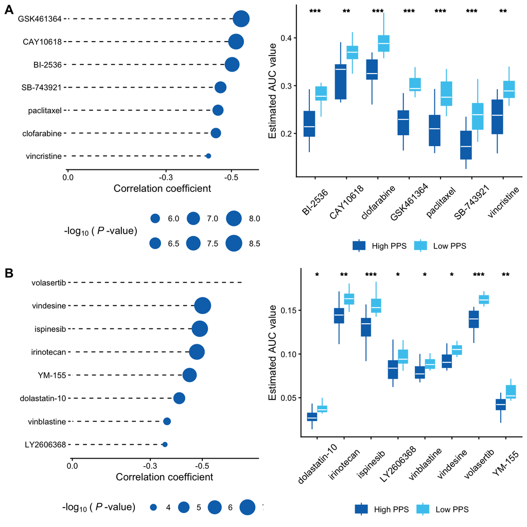

```r
plot_grid(p1, p3, p2, p4, labels=c("A", "", "B", ""),
          ncol=2,
          rel_widths = c(2, 2)) # 左右两列的宽度比例 the width ratio of the left and right columns
```

```r
ggsave(filename = "drug target.pdf",width = 8,height = 8)

# 保存镜像 Save image
#save.image("drug.RData")
```